# Students Performance Exams score by Jawaher AlDamegh

```
## [1] "gender"                      "race.ethnicity"
## [3] "parental.level.of.education" "lunch"
## [5] "test.preparation.course"     "math.score"
## [7] "reading.score"               "writing.score"
```

> This Students Performance dataset contains 1,000 obersvations with 8 variables, I will do some analyzing to determine which gender reach the highest score in Math, reading and writing subjects.

# Univariate Plots Section

```
## [1] "gender"                      "race.ethnicity"
## [3] "parental.level.of.education" "lunch"
## [5] "test.preparation.course"     "math.score"
## [7] "reading.score"               "writing.score"
```

```
##     gender    race.ethnicity     parental.level.of.education
##  female:518   group A: 89    associate's degree:222
##  male  :482   group B:190    bachelor's degree :118
##               group C:319    high school       :196
##               group D:262    master's degree   : 59
##               group E:140    some college      :226
##                              some high school  :179
##           lunch     test.preparation.course   math.score
##  free/reduced:355   completed:358           Min.   :  0.00
##  standard    :645   none     :642           1st Qu.: 57.00
##                                             Median : 66.00
##                                             Mean   : 66.09
##                                             3rd Qu.: 77.00
##                                             Max.   :100.00
##  reading.score    writing.score
##  Min.   : 17.00   Min.   : 10.00
##  1st Qu.: 59.00   1st Qu.: 57.75
##  Median : 70.00   Median : 69.00
##  Mean   : 69.17   Mean   : 68.05
##  3rd Qu.: 79.00   3rd Qu.: 79.00
##  Max.   :100.00   Max.   :100.00
```

> As shown in above summary, the lowest degrees in math is 0 while the writing is 10 and reading 17. So We can say that there is a defect in math subject that may happend because the student didn’t attend to the test or that may resulted by the way of teaching or the student has weakness in math. To solve this issue we should change the method of how teaching mathematics or improve the performance of students, for example, by adding more classes.

> While it is clear to us that the average scores in all tests (the 3 subjects) are convergent and this is a good sign.

# Univariate Analysis

### What is the structure of your dataset?

> As previously described, my dataset contain 1,000 observations of 8 variables.

### What we can observe from this dataset?

> I will apply some visualizations to answer the question:

```
##
## female   male
##    518    482
```

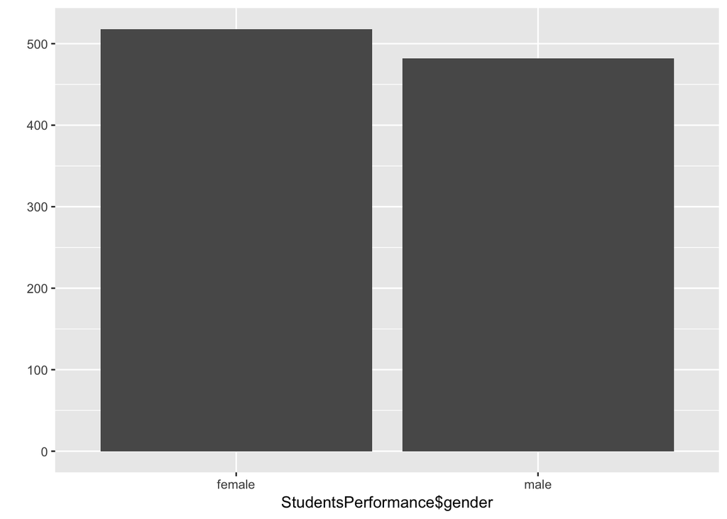

> The female in this dataset are more then male as appear.

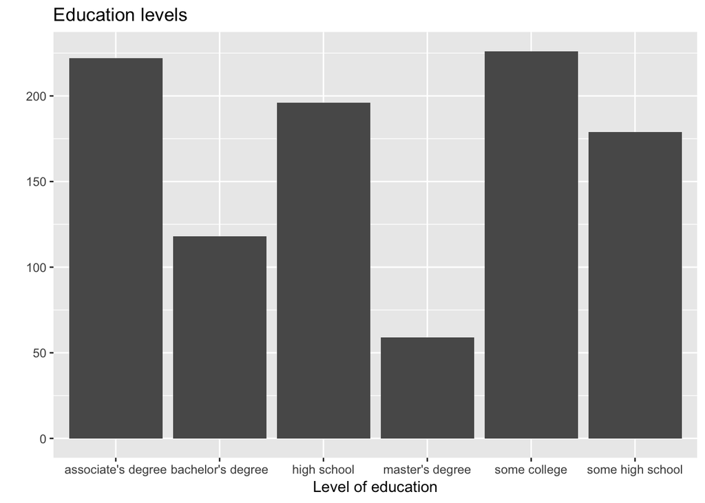

```
##
##                      female male
##   associate's degree    116  106
##   bachelor's degree      63   55
##   high school            94  102
##   master's degree        36   23
##   some college          118  108
##   some high school       91   88
```

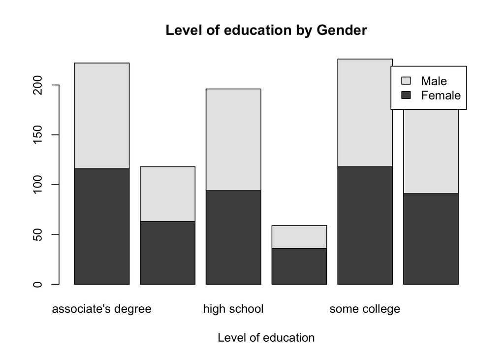

# Bivariate Plots Section

> **In this section** we will refer two variables toghter, then we will analyze them to reach a clear results about our dataset by answuring some questions:

### Which major factors contribute to test outcomes?

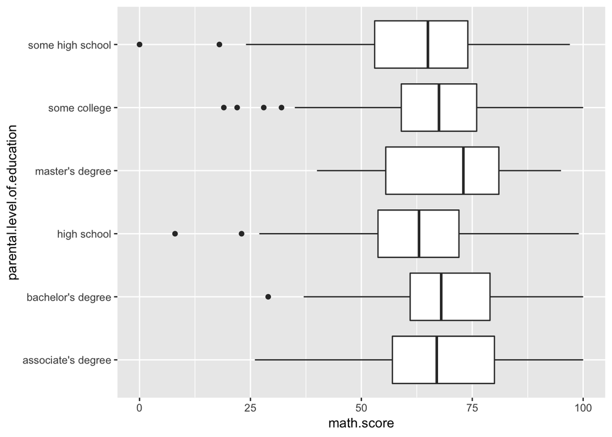

> As observed that the average scores that around 75 (which is the highest) obtained by the master’s degree student in math subject.

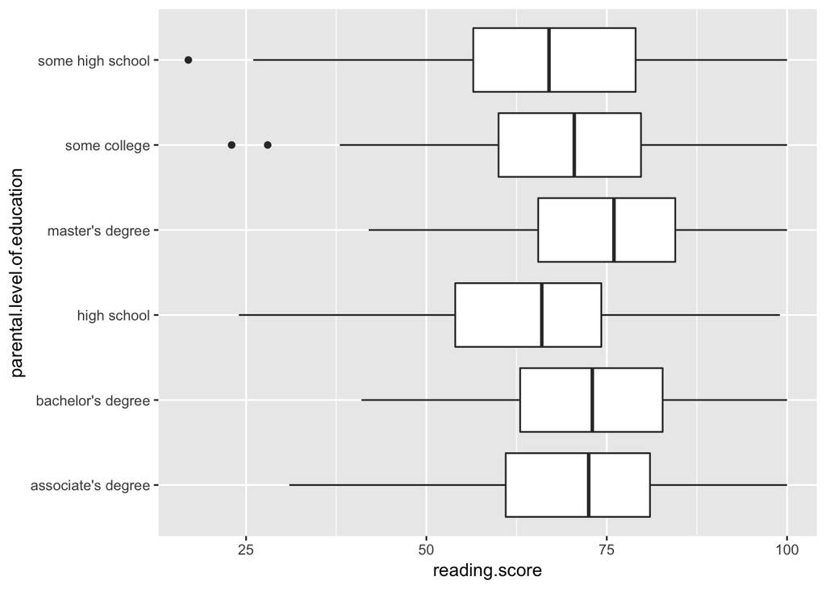

> Regarding the reading subject the master’s degree students obtained highest average scores which is 75 score.

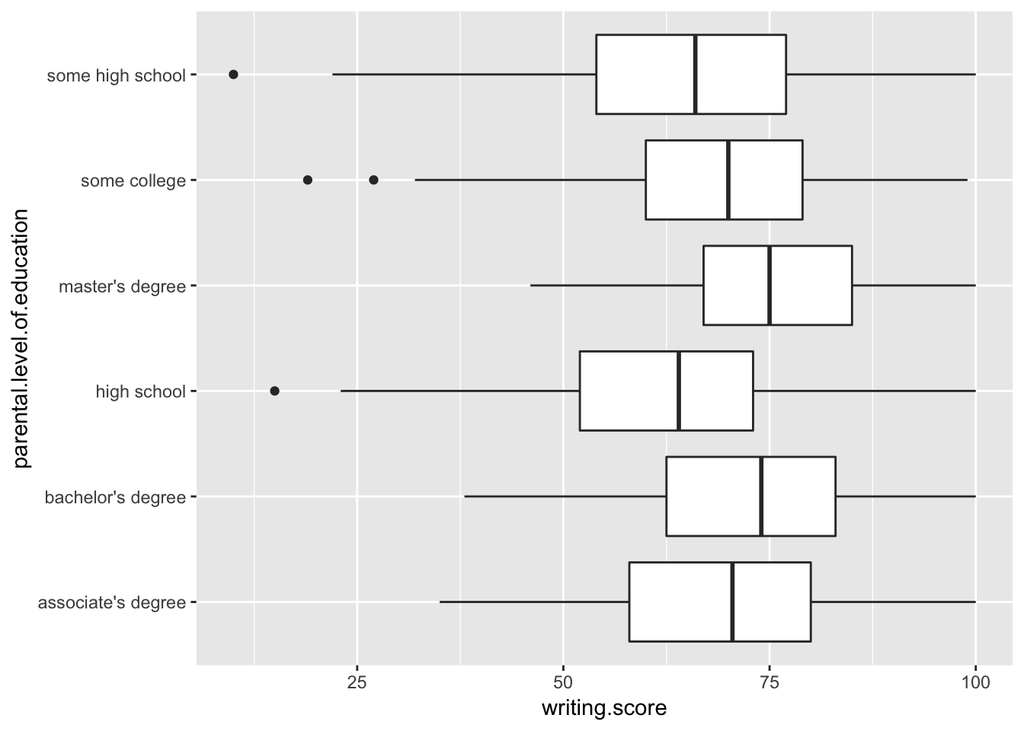

> Here also we observed that the master’s degree students obtained highest average scores in writing subject which is 75 score.

### Specify who completed the test preparation course more if they are female or male?

```
##
##             female male
##   completed    184  174
##   none         334  308
```

> We observed that the number of female who did this test preparation are more than the male regardless of the small difference.

# Bivariate Analysis

### Talk about some of the relationships you observed in this part of the . How did the feature(s) of interest vary with other features in dataset?

## Subjects VS. Race.ethnicity:

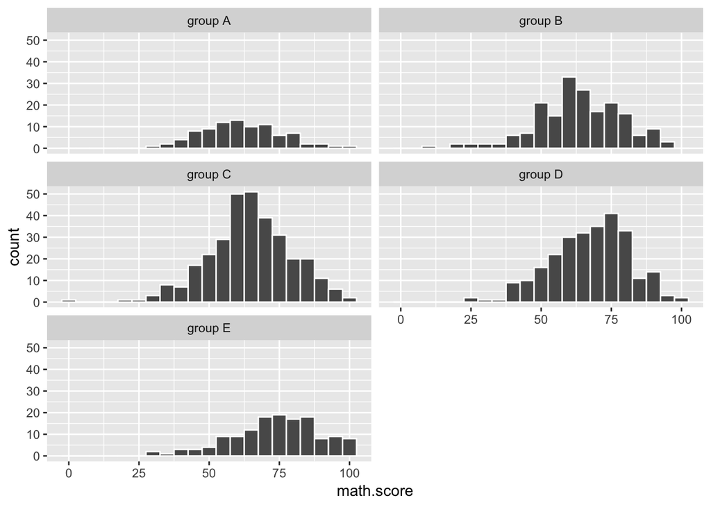

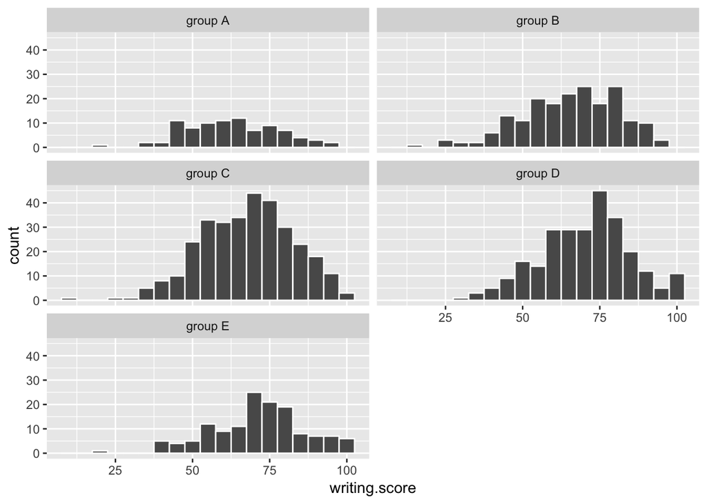

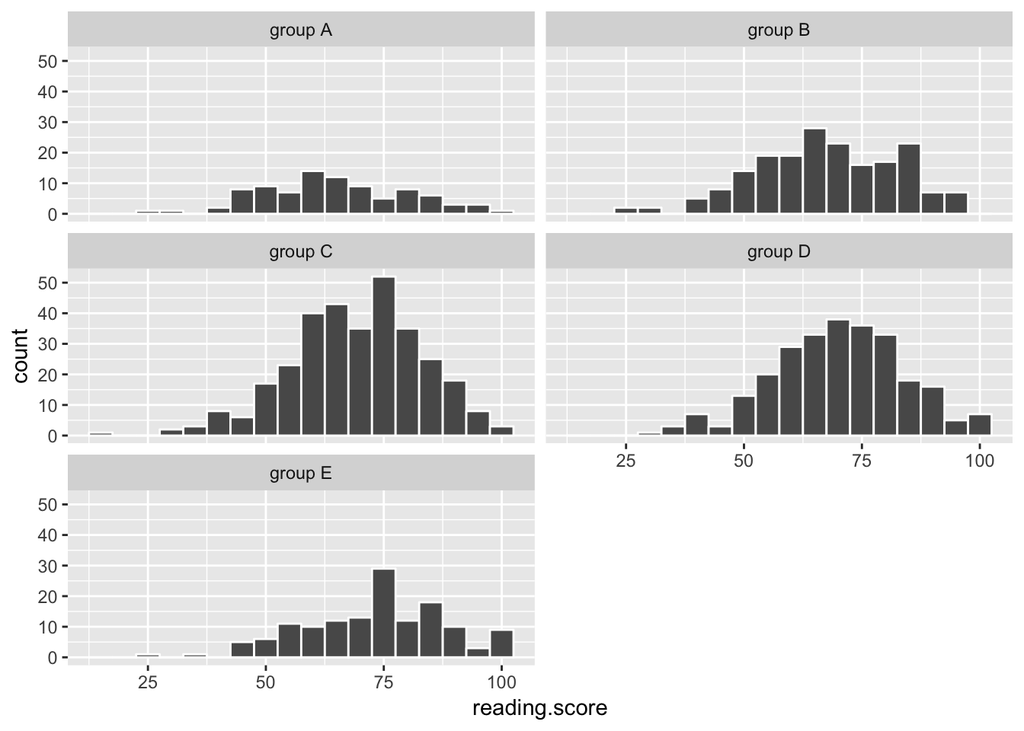

### Did you observe any interesting relationships between the other features (not the main feature(s) of interest)?

## Subjects VS. Gender:

> **In this section** we will find the relationship between the math, reading and writing scores and gender to see who gained more scores female or male.

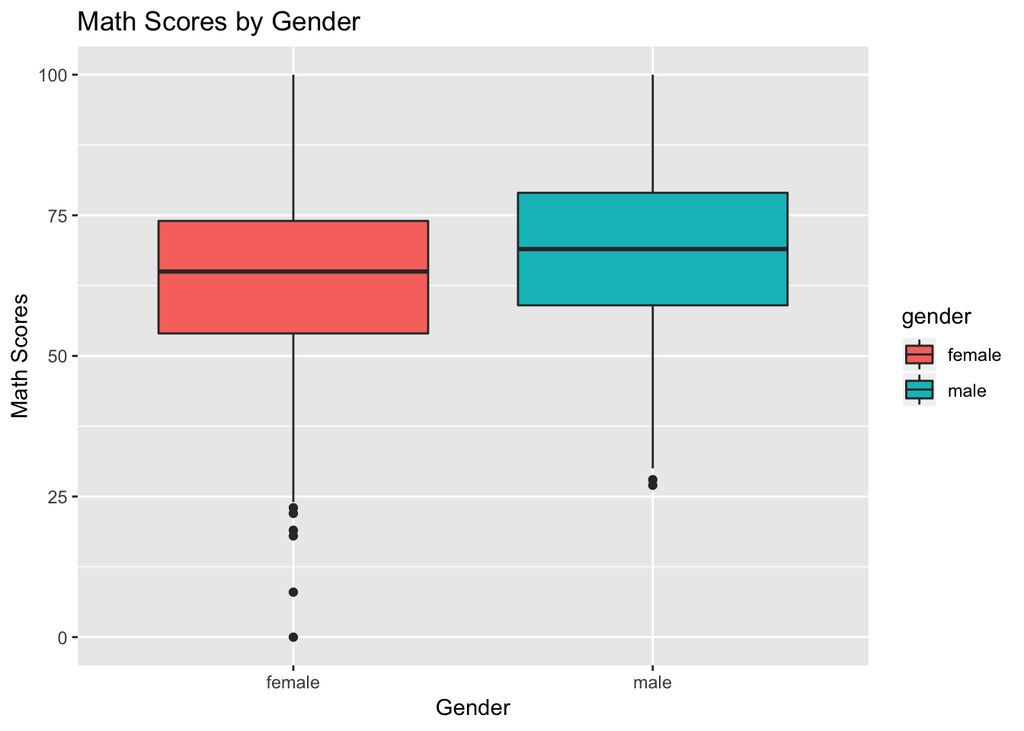

> As shown, male gained more scores than the female.

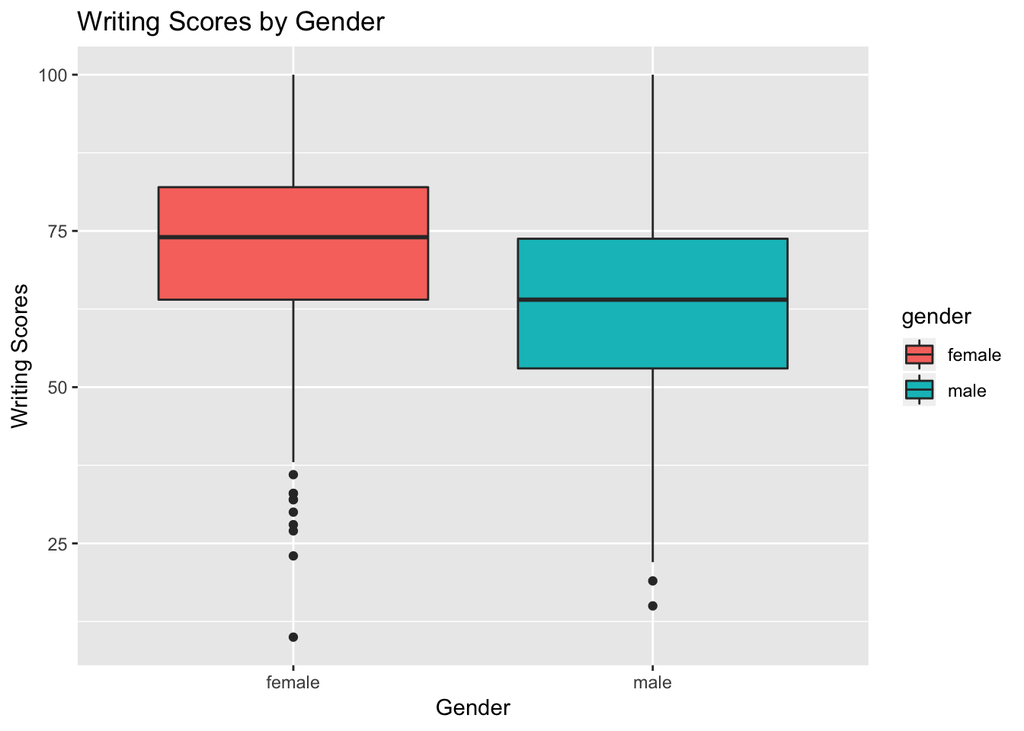

> In a clear deferincess female has the highest avrage than the male.

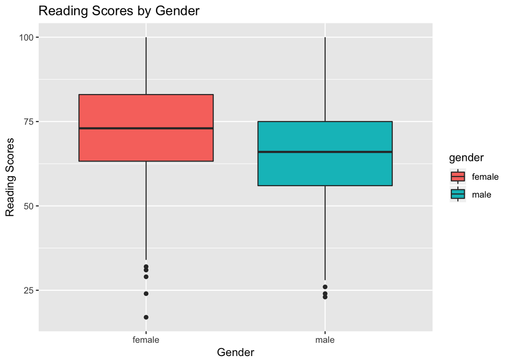

> By a clear margin we can see that the female obtained a higher scores in reading subject than the male.

# Multivariate Plots Section & Multivariate Analysis

> **In this section** We will combine more than two variables together to see the correlations between these variables:

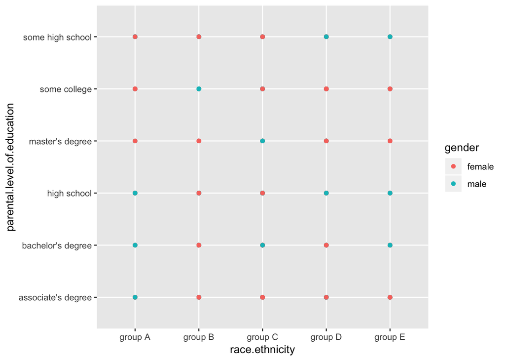

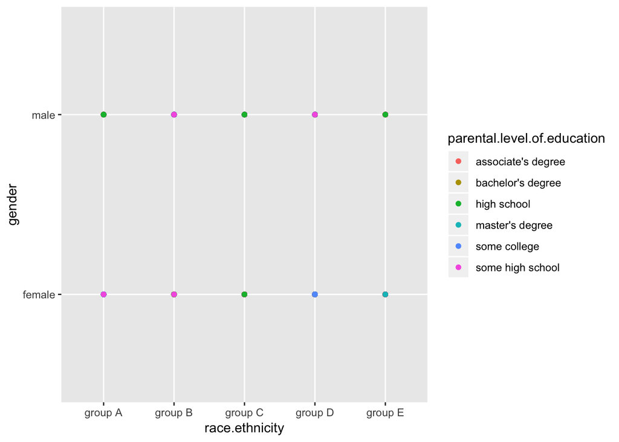

# Final Plots and Summary

### Plot One

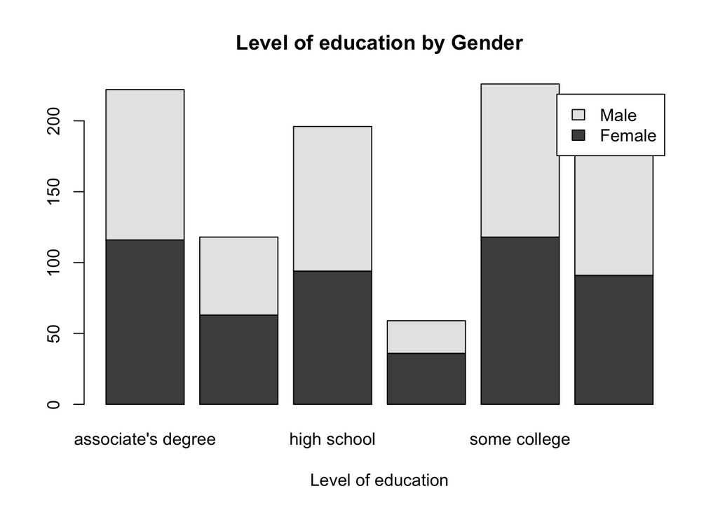

### Plot Two

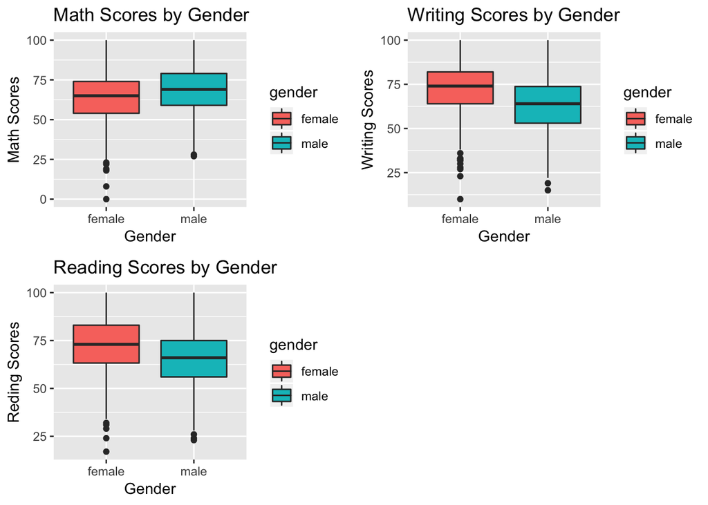

### Plot Three

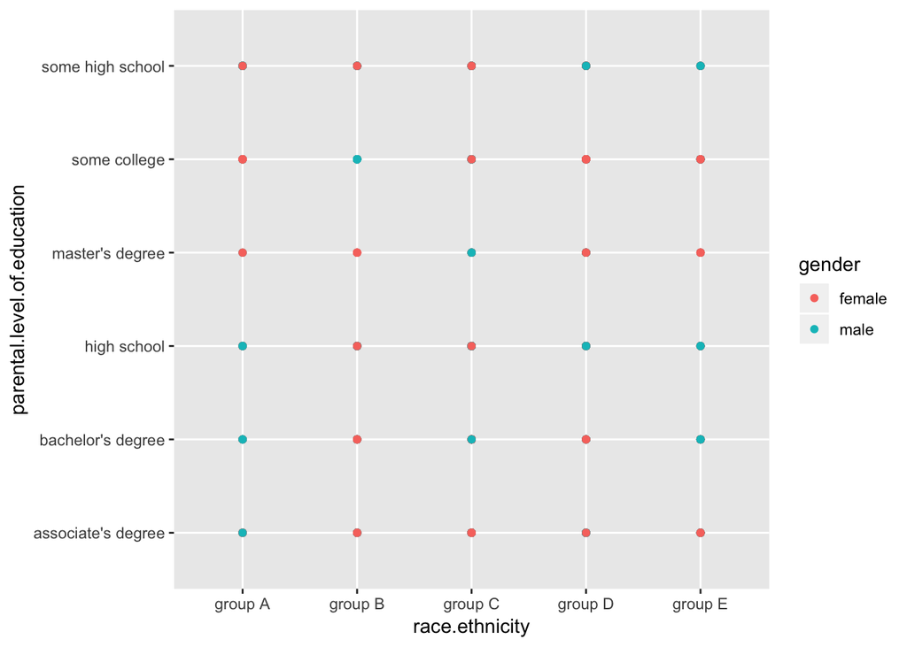

### Description Three

# Reflection

> This dataset includes scores from three exams and a variety of personal, social, and economic factors that have interaction effects upon them.

> The dataset contain 1,000 observations and 8 variables.

> We start our analysis with summuraize all data so we can choose the most affictive variables to start with it such as:

> **Gender:** is the most affective variable to see how many female and male in this test.

> **parental.level.of.education:** it’s also important variable.

> **math,reading and writing score:** are the main variables that affect our analysis.

> At the end, I found that the dataset was very impressive to me and I joyable to did this analyze.

> **Future improvement** can be made if more data can be collected as we can answer the question below: - What would be the best way to improve student scores on each test? If the data set has more records and information the quality of analysis can be improved and this question and other will be answered.

# References

https://www.rstudio.com/wp-content/uploads/2016/11/ggplot2-cheatsheet-2.1.pdf